# Realisztikus Mortalitási Görbe Generálása

Varga Zoltan

2025-09-22

## **Bevezetés**

A halandósági görbék értelmezése és vizsgálata lehetővé teszi a kutatók számára, hogy elemezzék, miként változnak a halálozási mintázatok az időben. Másképpen fogalmazva: a halandósági görbék betekintést nyújtanak a halálozás alakulásába és annak szerkezetébe. Ezek az elemzések kulcsszerepet játszanak a demográfiai és epidemiológiai kutatásokban, mivel feltárják, hogy a hpsszú távú trendek, szezonális hatások és a váratlan sokkok miként formálják a halálozást a populációkban. Emellett a halandósági görbék kiemelten fontosak a többlethalálozás vizsgálatában. A többlethalálozás becslésekor különösen fontos, hogy a “normál” időszakokra vonatkozó, realisztikus halálozási mintázatot ismerjük.

A vizsgálat egyik jól bevállt módszertana, hogy a modellt elsőnek egy generált, realisztikusa adatsoron teszteljük, majd a kapott eredményeket összehasonlítjuk egymással. Ennek érdekében a realisztikus haladósági görbék előállítása elengedhetetlen a módszertani fejlesztésekhez és a statisztikai modellek teszteléséhez.

A szintetikus tesztadatok előállítása több okból kritikus:

- objektív összehasonlítást tesz lehetővé különböző modellek között,
- lehetőséget ad módszertani fejlesztések kiértékelésére
- kiküszöböli a valós adatokból eredő hibát, adatminőségi problémákat.

### A modell matematikai leírása

A szimulált halandósági görbe az alábbi komponensek összegzésével jön létre:

1. Időskála
2. Deomgráfiai szerkezet és trend
3. Bázis halálozási ráta
4. Szezonalitás
5. Rövid idejű sokkok
6. Véletlen zaj hatás

# **Megvalósítás**

## 1. Könyvtárak betöltése

```r
# ---------------------------------------------------------------
# Könyvtárak betöltése
# Ezek szükségesegk az adattisztításhoz, időkezeléshez,
# táblázatformázáshoz és az adatvizualizációhoz.
# ---------------------------------------------------------------
library(dplyr)
library(lubridate)
library(tidyr)
library(kableExtra)
library(knitr)
library(ggplot2)
library(scales)
```

## 2. Korcsoportok konfigurációja

```r
# ---------------------------------------------------------------
# Korcsoport konfigurációs adatok létrehozása
# ---------------------------------------------------------------
nmb_week <- 52.18 # Az év heteinek átlagos száma

age_groups <- tibble::tibble(
  labels = c("0-4","5-9","10-14","15-19","20-24",
            "25-29","30-34","35-39","40-44","45-49",
            "50-54","55-59","60-64","65-69","70-74",
            "75-79","80+"),

  # induló népesség-arány
  share_start = c(0.045,0.046,0.05,0.048,0.052,
                  0.053,0.061,0.065,0.064,0.069,
                  0.072,0.074,0.071,0.066,0.06,
                  0.048,0.056),

  # éves arány trend
  share_trend_per_year = c(-0.0014,-0.0014,-0.0012,-0.0010,-0.0009,
                           -0.0008,-0.0006,-0.0004,-0.0002,0.0000,
                           0.0001,0.0002,0.0004,0.0010,0.0014,
                           0.0020,0.0032),

  # éves halálozási ráták (százalék), hetekre átszámítva
  rate_base = c(
    0.13,  # 0-4
    0.05,  # 5-9
    0.05,  # 10-14
    0.06,  # 15-19
    0.07,  # 20-24
    0.08,  # 25-29
    0.09,  # 30-34
    0.11,  # 35-39
    0.13,  # 40-44
    0.20,  # 45-49
    0.32,  # 50-54
    0.47,  # 55-59
    0.70,  # 60-64
    1.08,  # 65-69
    2.50,  # 70-74
    4.50,  # 75-79
    7.50   # 80+
  ) / 100 / nmb_week,

  # éves trend a rátára
  rate_trend_per_year = c(-0.021853,-0.016853,-0.014853,-0.006853,-0.004853,
                          -0.002853,-0.000853,0.001147,0.003147,0.004147,
                          0.005147,0.006147,0.007147,0.008147,0.009147,
                          0.010147,0.014647),

  # szezonalitás amplitúdói
  amp1 = seq(0.03, 0.18, length.out = 17),
  amp2 = seq(0.01, 0.05, length.out = 17)
)


# Trendmeredekségek hozzárendelése korcsoporotnként
slopes <- seq(-0.01, 0.008, length.out = 17)
```

## 3. Segédfüggvények

```r
# -------------------------------------------------------------------
# 1) Heti dátumindex előállítása
#
# Ez a függvény egy kezdő- és egy záró dátum között generál egy
# heti felbontású date-sorozatot.
#
# Paraméterek:
#   start: karakterlánc, a kezdődátum (YYYY-MM-DD)
#   end:   karakterlánc, a záródátum (YYYY-MM-DD)
#
# Kimenet:
#   Date vektor, amely "week" lépésközzel halad.
#
# Használata:
#   weekly_index("2023-01-01", "2023-12-31")
# -------------------------------------------------------------------
weekly_index <- function(start="2015-01-05", end="2015-12-29") {
  seq.Date(as.Date(start), as.Date(end), by = "week")
}

wkl_ndx <- weekly_index(start="2023-01-01", end="2023-12-31") # heti dátumindex előállításának használata
#head(weekly_index(start="2023-01-01", end="2023-12-31"), 10) # printelés


# -------------------------------------------------------------------
# 2) Évbeli fázis számítása
#
# A szezonális komponenst meghatározó szinuszfüggvény miatt fontos,
# hogy a dátumot 0–1 intervallumra skálázzuk, ahol:
#   0   ~ január 1.
#   0.5 ~ július közepe
#   1   ~ december vége
#
# Paraméter:
#   dates – Date vektor
#
# Kimenet:
#   numeric vektor 0 és 1 között
# -------------------------------------------------------------------
year_fraction <- function(dates) {
  (yday(dates) - 1) / 365.25 # a dátum éven belüli arányra képzése.
}


# -------------------------------------------------------------------
# 3) Szezonális multiplikátor (Fourier-bővítéssel)
#
# A szezonális moduláció a halandósági ráta időbeli periodikus
# ingadozását modellezi.
#
# Paraméterek:
#   dates    – Date vektor
#   amp1     – az éves fő komponenst szabályozó amplitúdó
#   amp2     – a fél éves második komponens amplitúdója
#   phase    – fáziseltolás, amely meghatározza, hová essen a maximum
#
# Kimenet:
#   numeric vektor, multiplikatív szezonális szorzó
# -------------------------------------------------------------------
seasonal_multiplier <- function(dates, amp1=0.12, amp2=0.04, phase = 0.08) {
  y <- year_fraction(dates)
  1 + amp1 * sin(2*pi*(y - phase)) + amp2 * sin(4*pi*(y - phase))
}


# -------------------------------------------------------------------
# 4) Trendmultiplikátor: lineáris vagy exponenciális modell
#
# Paraméterek:
#   dates           – Date vektor
#   slope_per_year  – éves meredekség; lehet skalár vagy vektor
#   ref_date        – ehhez viszonyítjuk az eltelt évek számát
#   type            – "exp" (exponenciális) vagy "linear"
#
# Ha slope_per_year vektor (pl. korcsoportonkénti trend),
# a függvény egy N×G mátrixot ad vissza.
# -------------------------------------------------------------------
trend_multiplier <- function(dates,
                             slope_per_year = 0, # lehet skalár vagy vektor (pl. korcsoportonként)
                             ref_date = min(dates), # ehhez képest számoljuk az eltelt időt
                             type = c("exp", "linear")) {

  type <- match.arg(type)

  t_years <- as.numeric(as.Date(dates) - as.Date(ref_date)) / 365.25 # eltelt évek

  # Ha a slope_per_year vektor, térjük vissza n x G mátrixszal
  if (length(slope_per_year) > 1L) {
    S <- matrix(slope_per_year, nrow = length(t_years), ncol = length(slope_per_year), byrow = TRUE)
    T <- matrix(t_years, nrow = length(t_years), ncol = length(slope_per_year), byrow=FALSE)
    if (type == "exp") {
      return( (1 + S)^T )
    } else {
      return( 1 + S*T )
    }
  } else {
    # skalár meredekség -> vektor
    s <- slope_per_year
    if (type == "exp") {
      return( (1 + s)^t_years )
    } else {
      return( 1 + s*t_years)
    }
  }
}

dates <- weekly_index(start="2023-01-02", end="2023-12-25")
trend_mat <- trend_multiplier(dates, slope_per_year = slopes, type="exp")


# -------------------------------------------------------------------
# 5) Sztochasztikus halálozásszámok generálása
#
# Paraméterek:
#   mu            – várt érték (mátrix vagy vektor)
#   distribution  – "deterministic", "poisson", "gamma_poisson"
#   nb_size       – overdiszperziós paraméter (nagy -> kisebb szórás)
#   seed          – replikálhatóság
#
# Kimenet:
#   szimulált halálozási számok
# -------------------------------------------------------------------
draw_counts <- function(mu,
                        distribution = c("deterministic", "poisson", "gamma_poisson"),
                        nb_size = 10, # overdiszperzió: nagyobb = kevesebb szórás
                        seed = NULL) {

  distribution <- match.arg(distribution)

  #lapítsuk vektorra
  mu_vec <- as.vector(mu)
  mu_vec <- pmax(mu_vec, 0) # negatív numerikus zaj ellen biztosíték

  if (!is.null(seed)) set.seed(seed)

  if (distribution == "deterministic") {
    return(mu_vec)
  } else if (distribution == "poisson") {
    return(stats::rpois(length(mu_vec), lambda = mu_vec))
  } else {
    size_vec <- if (length(nb_size) == 1L) rep(nb_size, length(mu_vec)) else nb_size
    return(stats::rnbinom(length(mu_vec), size = size_vec, mu = mu_vec))
  }
}


# -------------------------------------------------------------------
# 6) Téli sokk generálása (pl. influenza-szezon)
#
# Matematikai forma:
#   ha t < peak: exp(t / rise)
#   ha t > peak: exp(-t / decay)
#
# Paraméterek:
#   peak_date       – minden évben a csúcs dátuma (MM-DD)
#   rise_weeks      – felfutási sebesség
#   decay_weeks     – lecsengés sebessége
#   age_sensitivity – sokk nagysága
#   random_intensity– hozzáadott zaj mértéke
# -------------------------------------------------------------------
shock_multiplier <- function(dates,
                             peak_date = "01-25", # minden évben január 25 a téli csúcs
                             rise_weeks = 2,
                             decay_weeks = 6,
                             age_sensitivity = 0.3,
                             random_intensity = 0.05,
                             seed = NULL) {

  if (!is.null(seed)) set.seed(seed)

  years <- unique(format(dates, "%Y"))

  shock_list <- lapply(years, function(y) {
    peak_date <- as.Date(paste0(y, '-', peak_date))
    t_weeks <- as.numeric(as.Date(dates) - peak_date) / 7

    shape <- ifelse(t_weeks < 0,
                    exp(t_weeks / rise_weeks),    # gyors felfutás
                    exp(-t_weeks / decay_weeks))  # lassú lefutás

    base <- 1 + age_sensitivity * shape

    noise <- rnorm(length(dates), 0, random_intensity)
    base * (1 + noise)

  })

  shock_total <- Reduce('*', shock_list)

  shock_total[shock_total < 0] <- 0
  return(shock_total)
}


# -------------------------------------------------------------------
# 7) Nyári sokk generálása (pl. hőhullám)
#
# Paraméterek megegyeznek a téli sokkéval,
# csak az időtartam és erősség jellemzően rövidebb.
# -------------------------------------------------------------------
shock_multiplier_summer <- function(dates,
                                    peak_date = "07-20",      # július 20 körül nyári csúcs
                                    rise_weeks = 1,
                                    decay_weeks = 1,
                                    age_sensitivity = 0.3,
                                    random_intensity = 0.05,
                                    seed = NULL) {

  if (!is.null(seed)) set.seed(seed)

  years <- unique(format(dates, '%Y'))

  shock_list <- lapply(years, function(y) {
    peak_date <- as.Date(paste0(y, '-', peak_date))
    t_weeks <- as.numeric(as.Date(dates) - peak_date) / 7

    shape <- ifelse(t_weeks < 0,
                    exp(t_weeks / rise_weeks),
                    exp(-t_weeks / decay_weeks))

    base <- 1 + age_sensitivity * shape
    noise <- rnorm(length(dates), 0, random_intensity)

    base * (1 + noise)


  })

  shock_total <- Reduce("*", shock_list)

  shock_total[shock_total < 0] <- 0
  return(shock_total)
}
```

## 4. Korcsoportonkénti szimuláció

```r
# ===================================================================
#   TÖBB KORCSOPORT EGYÜTTES MORTALITÁSI SZIMULÁCIÓJA
#
#   simulate_mortality()
#
#   Ez a függvény a megadott időszakra több korcsoportra generál
#   realisztikus halálozási adatokat. A modell komponensei:
#
#     - demográfiai korcsoport-arányok időbeli változása
#     - korcsoportonként eltérő alap halálozási ráta
#     - hosszú távú trend (exponenciális)
#     - szezonális komponens (Fourier-összetevők)
#     - téli influenza-sokk (exponenciális felfutás-lecsengés)
#     - nyári hőhullám-sokk (rövid, intenzív)
#     - opcionálisan Poisson vagy Gamma–Poisson zaj
#
#   A kimenet:
#       - "long" adatkeret: minden dátum × korcsoport × komponens
#
# ===================================================================
simulate_mortality <- function(
    age_groups,
    slopes,
    start = "2001-01-01",
    end = "2023-12-25",
    population = 9700000,
    season_phase = 0.08,
    weeks_per_year = 52.1775,
    distribution = c("deterministic", "poisson", "gamma_poisson"),
    nb_size = 10,
    seed = NULL) {


  distribution <- match.arg(distribution)


  # ---------------------------------------------------------------
  # 1) Bemeneti ellenőrzés
  # ---------------------------------------------------------------
  req_cols <- c("labels","share_start","share_trend_per_year",
                "rate_base","rate_trend_per_year","amp1","amp2")
  stopifnot(all(req_cols %in% names(age_groups)))
  G <- nrow(age_groups)           # kocsoportok száma
  stopifnot(length(slopes) == G)  # ugyanannyi trend-meredekség legyen, mint korcsoport


  # ---------------------------------------------------------------
  # 2) Időskála felépítése (heti dátumindex)
  # ---------------------------------------------------------------
  dates   <- weekly_index(start, end)
  n       <- length(dates)
  t_years <- as.numeric(as.Date(dates) - as.Date(min(dates))) / 365.25


  # ---------------------------------------------------------------
  # 3) Demográfiai korcsoport-arányok időbeli változása
  #
  # share_g(t) = share_start_g + share_trend_g * t
  # A soronkénti normalizálás biztosítja, hogy mindig 1-re summázzon.
  # ---------------------------------------------------------------
  age_groups_over_time <- sapply(seq_len(G), function(g) {
    age_groups$share_start[g] + age_groups$share_trend_per_year[g]*t_years
  })
  age_groups_over_time_normalt <- age_groups_over_time / rowSums(age_groups_over_time)


  # ---------------------------------------------------------------
  # 4) Bázis halálozási ráta + trend
  #
  # rate_base(g) * (1 + rate_trend_g * t)
  #
  # A rate_base már hetekre van konvertálva a bemenetben.
  # ---------------------------------------------------------------
  rate_base_mort <- matrix(age_groups$rate_base, nrow = n, ncol = G, byrow=TRUE)
  rate_trend_mort <- sapply(seq_len(G), function(g) {
    (1 + age_groups$rate_trend_per_year[g] * t_years)
  })
  rate_mort <- rate_base_mort * rate_trend_mort


  # ---------------------------------------------------------------
  # 5) Szezonalitás korcsoportonként
  #
  # S_g(t) = 1 + a1_g sin(2π(y-phi)) + a2_g sin(4π(y-phi))
  # ---------------------------------------------------------------
  seasonal_mort <- sapply(seq_len(G), function(g) {
    seasonal_multiplier(
      dates,
      amp1 = age_groups$amp1[g],
      amp2 = age_groups$amp2[g],
      phase = season_phase
      )
  })


  # ---------------------------------------------------------------
  # 6) Hosszú távú trend (exponenciális modell)
  #
  # T_g(t) = (1 + slope_g)^t
  #
  # A trend_multiplier vektoros bemenet esetén egész mátrixot ad vissza.
  # ---------------------------------------------------------------
  trend_mort <- trend_multiplier(
    dates,
    slope_per_year = slopes,
    type="exp"
    )


  # ---------------------------------------------------------------
  # 7) Téli influenza-sokk korcsoportonként
  #
  # shape_g(t):
  #   t < peak_date  -> exp(t / rise_weeks)
  #   t > peak_date  -> exp(-t / decay_weeks)
  #
  # az age_sensitivity korcsoportonként nő → idősek érzékenyebbek
  # ---------------------------------------------------------------
  shock_mort <- sapply(seq_len(G), function(g) {
    shock_multiplier(
      dates,
      peak_date = "01-25",
      rise_weeks = 2,
      decay_weeks = 6,
      age_sensitivity = seq(0.05, 0.5, length.out = G)[g], # fiatal -> idősek
      random_intensity = 0.05,
      seed = 123
    )
  })


  # ---------------------------------------------------------------
  # 8) Nyári hőhullám-sokk korcsoportonként
  # ---------------------------------------------------------------
  shock_mort_summer <- sapply(seq_len(G), function(g) {
    shock_multiplier_summer(
      dates,
      peak_date = "07-20",
      rise_weeks = 1,
      decay_weeks = 1,
      age_sensitivity = seq(0.05, 0.5, length.out = G)[g],
      random_intensity = 0.05,
      seed = 123
    )
  })


  # ---------------------------------------------------------------
  # 9) A teljes mortalitási ráta összerakása
  #
  # mu_g(t) = rate × season × trend × winter_shock × summer_shock
  #
  # Multiplikatív modell -> faktoronként külön hatás.
  # ---------------------------------------------------------------
  mu_mort <- rate_mort *
    seasonal_mort *
    trend_mort *
    shock_mort *
    shock_mort_summer


  # ---------------------------------------------------------------
  # 10) A népesség korcsoport szerinti felosztása
  #
  # population_g(t) = share_g(t) * total_population
  # ---------------------------------------------------------------
  population_mort <- age_groups_over_time_normalt * population


  # ---------------------------------------------------------------
  # 11) Halálozások várható értéke:
  #
  # expected_deaths_g(t) = mu_g(t) × population_g(t)
  # ---------------------------------------------------------------
  mortality <- population_mort * mu_mort


  # ---------------------------------------------------------------
  # 12) Sztochasztikus halálesetszám generálás (opcionális)
  # ---------------------------------------------------------------
  deaths <- draw_counts(
    mu = mortality,
    distribution = distribution,
    nb_size = nb_size,
    seed = seed
  )


  # ---------------------------------------------------------------
  # 13) Kimenet összeállítása „tidy” (long) formátumban
  # ---------------------------------------------------------------
  long <- tibble::tibble(
    date = rep(dates, times = G),
    group = rep(age_groups$labels, each = n),
    share = as.vector(age_groups_over_time_normalt),
    rate_base = as.vector(rate_base_mort),
    rate_trend = as.vector(rate_trend_mort),
    seasonal = as.vector(seasonal_mort),
    trend = as.vector(trend_mort),
    mortality = as.vector(mortality),        # várható érték
    deaths = as.integer(round(deaths))
  )


  # ---------------------------------------------------------------
  # 14) Kimenet
  # ---------------------------------------------------------------
  list(long = long)
}


# ===================================================================
# FÜGGVÉNY HÍVÁSA
# ===================================================================
sim <- simulate_mortality(
  age_groups = age_groups,
  slopes = slopes,
  start = "2001-01-01",
  end   = "2023-12-25",
  population = 9700000,
  season_phase = 0.08,
  distribution = "deterministic",
  seed = 123
)
```

## 5. Eredmények táblázatos megjelenítése

```r
# ===================================================================
#   EREDMÉNYEK TÁBLÁZATOS MEGJELENÍTÉSE
#
#   Ebben a blokkban:
#     1) A sim$long kimenetet felhasználjuk
#     2) Korrigáljuk a 0–4 korcsoport halálozási értékeit
#        (az eredeti szimulációban ez megegyezik a 35–39 csoporttal)
#     3) A date × korcsoport mátrixot pivotáljuk széles formátumba
#     4) A kableExtra segítségével formázott táblázatot hozunk létre
#     5) CSV fájlba mentjük az eredményeket
# ===================================================================
long_df <- sim$long


# -------------------------------------------------------------------
# 1) Korrigálás: a 0–4 korcsoport halálozása legyen azonos a 35–39 csoporttal
#
# Megjegyzés:
#   A modellben egyes korcsoportok trendje/arányai azonosra sikerülhetnek
#   -> kutatási célból egyeztetjük a 0–4 értékeket a 35–39 csoporttal.
# -------------------------------------------------------------------
long_df <- long_df %>%
  group_by(date) %>%
  mutate(
    deaths = ifelse(group == "0-4",
                    deaths[group == "35-39"],
                    deaths),
    mortality = ifelse(group == "0-4",
                       mortality[group == "35-39"],
                       mortality)
  ) %>%
  ungroup()


# -------------------------------------------------------------------
# 2) Táblázat összeállítása széles formátumban:
#      minden sor egy dátum,
#      minden oszlop egy korcsoport,
#      érték: a heti halálozások száma.
# -------------------------------------------------------------------
df_results <- long_df |>
  dplyr::select(date, group, deaths) |>
  tidyr::pivot_wider(names_from = group, values_from = deaths) |>
  as.data.frame()


# -------------------------------------------------------------------
# 3) Táblázat megjelenítése kableExtra segítségével
# -------------------------------------------------------------------
kable(df_results,
      caption = "Eredmények korcsoportonként való megjelnítése",
      booktabs = TRUE) %>%
  kable_styling(bootstrap_options = c("striped", "hover", "condensed"),
                full_width = FALSE) %>%
  column_spec(1, bold = TRUE) %>%
  scroll_box(height = "350px")
```

Eredmények korcsoportonként való megjelnítése

| date | 0-4 | 5-9 | 10-14 | 15-19 | 20-24 | 25-29 | 30-34 | 35-39 | 40-44 | 45-49 | 50-54 | 55-59 | 60-64 | 65-69 | 70-74 | 75-79 | 80+ |
| --- | --- | --- | --- | --- | --- | --- | --- | --- | --- | --- | --- | --- | --- | --- | --- | --- | --- |
| 2001-01-01 | 8 | 3 | 3 | 3 | 4 | 5 | 7 | 8 | 10 | 16 | 27 | 41 | 58 | 83 | 175 | 251 | 487 |
| 2001-01-08 | 9 | 3 | 3 | 4 | 5 | 5 | 7 | 9 | 11 | 18 | 30 | 45 | 65 | 94 | 197 | 284 | 554 |
| 2001-01-15 | 19 | 6 | 6 | 7 | 9 | 11 | 14 | 19 | 22 | 37 | 63 | 95 | 137 | 199 | 421 | 611 | 1198 |
| 2001-01-22 | 14 | 4 | 4 | 5 | 7 | 8 | 10 | 14 | 16 | 27 | 46 | 71 | 103 | 150 | 320 | 468 | 923 |
| 2001-01-29 | 21 | 6 | 7 | 8 | 10 | 12 | 16 | 21 | 25 | 43 | 73 | 112 | 163 | 239 | 512 | 751 | 1489 |
| 2001-02-05 | 30 | 9 | 10 | 11 | 15 | 17 | 23 | 30 | 36 | 61 | 104 | 160 | 233 | 340 | 729 | 1071 | 2122 |
| 2001-02-12 | 6 | 2 | 2 | 2 | 3 | 4 | 5 | 6 | 7 | 13 | 22 | 33 | 48 | 71 | 151 | 222 | 440 |
| 2001-02-19 | 18 | 5 | 6 | 7 | 9 | 10 | 14 | 18 | 22 | 37 | 62 | 96 | 139 | 203 | 436 | 640 | 1268 |
| 2001-02-26 | 23 | 6 | 7 | 8 | 11 | 13 | 17 | 23 | 27 | 45 | 77 | 118 | 172 | 251 | 539 | 791 | 1569 |
| 2001-03-05 | 10 | 3 | 3 | 4 | 5 | 6 | 8 | 10 | 12 | 21 | 36 | 55 | 79 | 116 | 248 | 364 | 723 |
| 2001-03-12 | 9 | 3 | 3 | 4 | 5 | 5 | 7 | 9 | 11 | 19 | 32 | 49 | 71 | 103 | 221 | 325 | 645 |
| 2001-03-19 | 15 | 4 | 5 | 6 | 7 | 9 | 12 | 15 | 18 | 31 | 52 | 80 | 116 | 169 | 363 | 533 | 1056 |
| 2001-03-26 | 24 | 7 | 8 | 9 | 12 | 14 | 18 | 24 | 28 | 48 | 81 | 124 | 180 | 262 | 562 | 824 | 1634 |
| 2001-04-02 | 16 | 5 | 5 | 6 | 8 | 9 | 12 | 16 | 19 | 32 | 54 | 82 | 120 | 175 | 374 | 548 | 1087 |
| 2001-04-09 | 9 | 3 | 3 | 4 | 5 | 5 | 7 | 9 | 11 | 19 | 31 | 48 | 70 | 102 | 218 | 320 | 633 |
| 2001-04-16 | 15 | 4 | 5 | 6 | 7 | 9 | 11 | 15 | 18 | 29 | 50 | 76 | 111 | 161 | 345 | 506 | 1002 |
| 2001-04-23 | 12 | 4 | 4 | 5 | 6 | 7 | 9 | 12 | 14 | 24 | 41 | 62 | 90 | 131 | 280 | 410 | 812 |
| 2001-04-30 | 17 | 5 | 5 | 6 | 8 | 10 | 13 | 17 | 20 | 33 | 56 | 86 | 124 | 181 | 387 | 567 | 1122 |
| 2001-05-07 | 20 | 6 | 7 | 8 | 10 | 12 | 15 | 20 | 24 | 40 | 67 | 103 | 148 | 216 | 461 | 675 | 1335 |
| 2001-05-14 | 8 | 2 | 3 | 3 | 4 | 5 | 6 | 8 | 10 | 16 | 27 | 41 | 59 | 86 | 184 | 270 | 533 |
| 2001-05-21 | 18 | 6 | 6 | 7 | 9 | 11 | 14 | 18 | 22 | 36 | 61 | 93 | 135 | 196 | 417 | 610 | 1206 |
| 2001-05-28 | 10 | 3 | 3 | 4 | 5 | 6 | 7 | 10 | 12 | 19 | 33 | 50 | 72 | 104 | 221 | 324 | 639 |
| 2001-06-04 | 12 | 4 | 4 | 5 | 6 | 7 | 9 | 12 | 14 | 24 | 40 | 61 | 87 | 127 | 269 | 394 | 777 |
| 2001-06-11 | 23 | 7 | 8 | 9 | 11 | 13 | 17 | 23 | 27 | 45 | 75 | 114 | 164 | 238 | 506 | 739 | 1458 |
| 2001-06-18 | 26 | 8 | 9 | 10 | 13 | 15 | 20 | 26 | 30 | 51 | 85 | 129 | 186 | 269 | 572 | 835 | 1647 |
| 2001-06-25 | 18 | 6 | 6 | 7 | 9 | 11 | 14 | 18 | 21 | 36 | 60 | 92 | 132 | 191 | 405 | 592 | 1168 |
| 2001-07-02 | 14 | 4 | 5 | 5 | 7 | 8 | 11 | 14 | 16 | 28 | 46 | 70 | 101 | 147 | 312 | 456 | 901 |
| 2001-07-09 | 12 | 4 | 4 | 5 | 6 | 7 | 9 | 12 | 14 | 24 | 41 | 62 | 89 | 130 | 277 | 406 | 804 |
| 2001-07-16 | 14 | 4 | 4 | 5 | 7 | 8 | 11 | 14 | 17 | 28 | 48 | 73 | 106 | 155 | 334 | 493 | 982 |
| 2001-07-23 | 12 | 3 | 4 | 4 | 6 | 7 | 9 | 12 | 14 | 24 | 40 | 62 | 90 | 132 | 284 | 420 | 838 |

[output cut: 1170 more lines]

```r
# -------------------------------------------------------------------
# 4) CSV mentés (kutatási reproducibilitás érdekében)
# -------------------------------------------------------------------
write.csv(df_results,
          file = "df_results_23_years_version2.csv",
          row.names = FALSE)
```

## 6. Eredmények vizuális megjelenítése

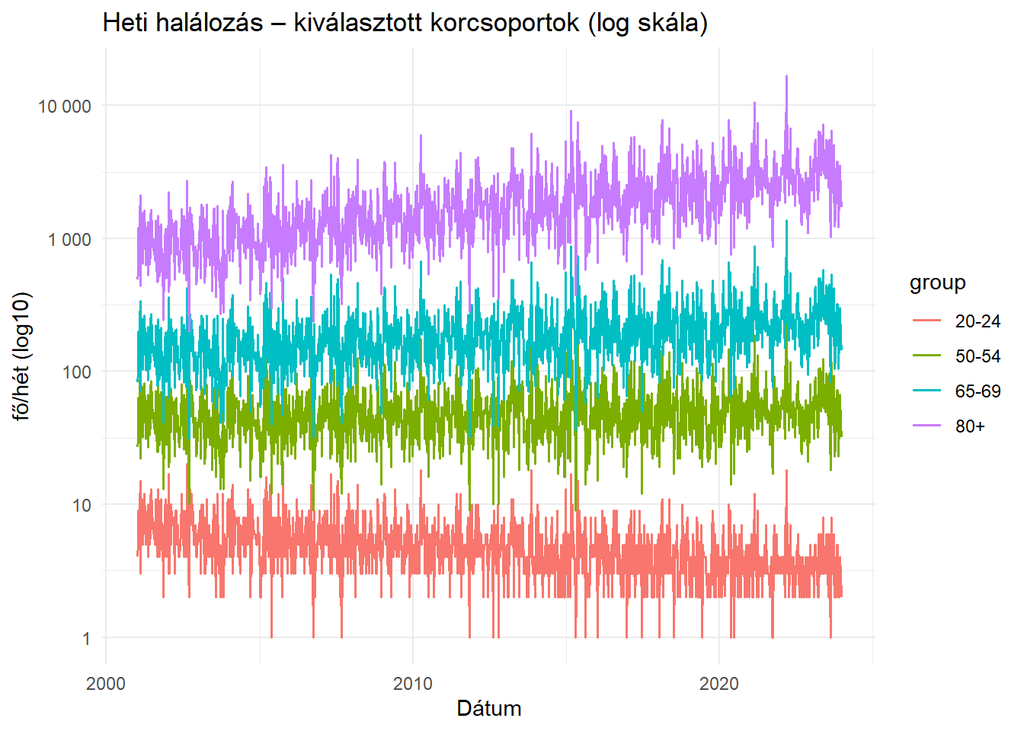

```r
# ===================================================================
#   EREDMÉNYEK VIZUÁLIS MEGJELENÍTÉSE
#
#   Lépések:
#     1) A széles táblázatot visszaalakítjuk hosszú formátumba
#     2) Kiválasztunk néhány reprezentatív korcsoportot
#     3) Idősoros ábrát készítünk logaritmikus Y-skálával
# ===================================================================

# -------------------------------------------------------------------
# 1) Átalakítás grafikonhoz: pivot_longer
# -------------------------------------------------------------------
df_long_for_plot <- df_results |>
  tidyr::pivot_longer(-date, names_to = "group", values_to = "death")


# -------------------------------------------------------------------
# 2) Kiválasztott korcsoportok vizsgálata
#
# Példa: fiatal – középkorú – idősebb – nagyon idősek
#
#   20–24
#   50–54
#   65–69
#   80+
# -------------------------------------------------------------------
sel_groups <- c("20-24", "50-54", "65-69", "80+")


# -------------------------------------------------------------------
# 3) Ábra: heti halálozások időben (log skála)
# -------------------------------------------------------------------
df_long_for_plot |>
  dplyr::filter(group %in% sel_groups) |>
  ggplot(aes(date, death, color = group)) +
  geom_line(linewidth = 0.6) +
  scale_y_log10(labels = label_number(accuracy = 1)) +
  labs(title = "Heti halálozás – kiválasztott korcsoportok (log skála)",
       x = "Dátum", y = "fő/hét (log10)") +
  theme_minimal()
```